# Recent changes in grid graphics

Abstract

“Recent changes in grid graphics” published in R News.

## Introduction

The **grid** graphics package provides an alternative graphics system to the “traditional” S graphics system that is provided by the **graphics** package.

The majority of high-level plotting functions (functions that produce whole plots) that are currently available in the base packages and in add-on packages are built on the **graphics** package, but the **lattice** package (Sarkar, 2002), which provides high-level Trellis plots, is built on **grid**.

The **grid** graphics package can be useful for customising **lattice** plots, creating complex arrangements of several **lattice** plots, or for producing graphical scenes from scratch.

The basic features of **grid** were described in an R News article in June 2002 (Murrell, 2002). This article provides an update on the main features that have been added to **grid** since then. This article assumes a familiarity with the basic **grid** ideas of units and viewports.

## Changes to grid

The most important organisational change is that **grid** is now a “base” package, so it is installed as part of the standard R installation. In other words, package writers can assume that **grid** is available.

The two main areas where the largest changes have been made to **grid** are viewports and graphical objects. The changes to viewports are described in the next section and summarised in Table 1 at the end of the article. A separate section describes the changes to graphical objects with a summary in Table 2 at the end of the article.

## Changes to viewports

**grid** provides great flexibility for creating regions on the page to draw in (viewports). This is good for being able to locate and size graphical output on the page in very sophisticated ways (e.g., **lattice** plots), but it is bad because it creates a complex environment when it comes to adding further output (e.g., annotating a **lattice** plot).

The first change to viewports is that they are now much more persistent; it is possible to have any number of viewports defined at the same time.

There are also several new functions that provide a consistent and straightforward mechanism for navigating to a particular viewport when several viewports are currently defined.

A viewport is just a rectangular region that provides a geometric and graphical context for drawing. The viewport provides several coordinate systems for locating and sizing output, and it can have graphical parameters associated with it to affect the appearance of any output produced within the viewport. The following code describes a viewport that occupies the right half of the graphics device and within which, unless otherwise specified, all output will be drawn using thick green lines. A new feature is that a viewport can be given a name. In this case the viewport is called “rightvp”. The name will be important later when we want to navigate back to this viewport.

```
> vp1 <- viewport(x=0.5, width=0.5,
                  just="left",
                  gp=gpar(col="green", lwd=3),
                  name="rightvp")
```

The above code only creates a description of a viewport; a corresponding region is created on a graphics device by *pushing* the viewport on the device, as shown below.[^1]

```
> pushViewport(vp1)
```

Now, all drawing occurs within the context defined by this viewport until we change to another viewport. For example, the following code draws some basic shapes, all of which appear in the right half of the device, with thick green lines (see the right half of Figure 1). Another new feature is that a name can be associated with a piece of graphical output. In this case, the rectangle is called “rect1”, the line is called “line1”, and the set of circles are called “circles1”. These names will be used later in the section on “Changes to graphical objects”.

[output not shown]

```
name="circles1")
> grid.lines(x[c(2, 1, 3, 4)],
  y[c(2, 1, 3, 4)],
  name="line1")
```

There are two ways to change the viewport. You can *pop* the viewport, in which case the region is permanently removed from the device, or you can navigate *up* from the viewport and leave the region on the device. The following code demonstrates the second option, using the `upViewport()` function to revert to using the entire graphics device for output, but leaving a viewport called “rightvp” still defined on the device.

```
> upViewport()
```

```
> vp2 <- viewport(x=0, width=0.5,
  just="left",
  gp=gpar(col="blue", lwd=3),
  name="leftvp")
> pushViewport(vp2)
> grid.rect(name="rect2")
> grid.circle(x, y, r=0.05,
  name="circles2")
> grid.lines(x[c(3, 2, 4, 1)],
  y[c(3, 2, 4, 1)],
  name="line2")
```

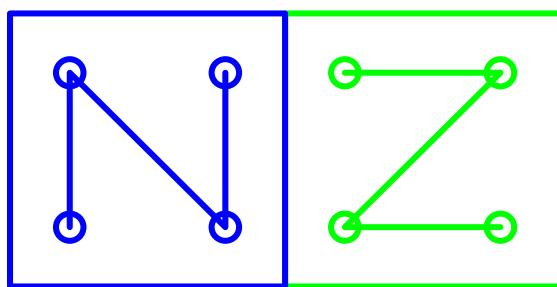

Figure 1: Some simple shapes drawn in some simple viewports.

There are now three viewports defined on the device; the function `current.vpTree()` shows all viewports that are currently defined.[^2]

```
> current.vpTree()
```

```
viewport[ROOT]->(
  viewport[leftvp],
  viewport[rightvp])
```

There is always a ROOT viewport representing the entire device and the two viewports we have created are both direct children of the ROOT viewport. We now have a tree structure of viewports that we can navigate around. As before, we can navigate up from the viewport we just pushed and, in addition, we can navigate *down* to the previous viewport. The function `downViewport()` performs the navigation to a viewport lower down the viewport tree. It requires the name of the viewport to navigate to. In this case, we navigate down to the viewport called “rightvp”.

```
> upViewport()
> downViewport("rightvp")
```

It is now possible to add further output within the context of the viewport called “rightvp”. The following code draws some more circles, this time explicitly grey (but still with thick lines; see Figure 2). The name “circles3” is associated with these extra circles.

```
> x2 <- 0.5 + 0.4*cos(c(r, r+pi/8, r-pi/8))
> y2 <- 0.5 + 0.4*sin(c(r, r+pi/8, r-pi/8))
> grid.circle(x2, y2, r=0.05,
  gp=gpar(col="grey"),
  name="circles3")
> upViewport()
```

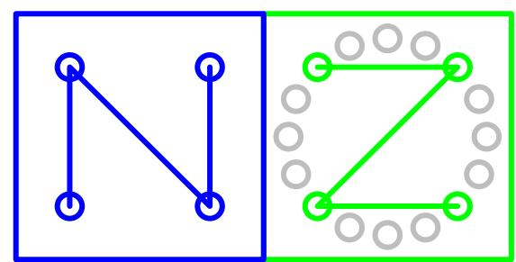

Figure 2: Navigating between viewports and annotating.

What this simple demonstration shows is that it is possible to define a number of viewports during drawing and leave them in place for others to add further output. A more sophisticated example is now presented using a **lattice** plot.[^3]

The following code creates a simple **lattice** plot. The “trellis” object created by the `histogram()` function is stored in a variable, `hist1`, so that we can use it again later; printing `hist1` produces the plot shown in Figure 3.[^4]

```
> hist1 <- histogram(
  par.settings=list(fontsize=list(text=8)),
  rnorm(500), type = "density",
  panel=
    function(x, ...) {
      panel.histogram(x, ...)
      panel.densityplot(x,
                        col="brown",
                        plot.points=FALSE)
    })
> trellis.par.set(canonical.theme("pdf"))
> print(hist1)
```

```
> current.vpTree()
```

```
viewport[ROOT]->(
  viewport[plot1.toplevel.vp]->(
    viewport[plot1.],
    viewport[plot1.panel.1.1.off.vp],
    viewport[plot1.panel.1.1.vp],
    viewport[plot1.strip.1.1.off.vp],
    viewport[plot1.xlab.vp],
    viewport[plot1.ylab.vp]))
```

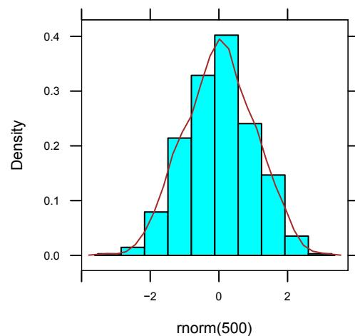

Figure 3: A simple lattice plot.

What we are going to do is add output to the **lattice** plot by navigating to a couple of the viewports that **lattice** set up and draw a border around the viewport to show where it is. We will use the `frame()` function defined below to draw a thick grey rectangle around the viewport, then a filled grey rectangle at the top-left corner, and the name of the viewport in white within that.

```
> frame <- function(name) {
  grid.rect(gp=gpar(lwd=3, col="grey"))
  grid.rect(x=0, y=1,
             height=unit(1, "lines"),
             width=1.2*stringWidth(name),
             just=c("left", "top"),
             gp=gpar(col=NA, fill="grey"))
  grid.text(name,
             x=unit(2, "mm"),
             y=unit(1, "npc") -
               unit(0.5, "lines"),
             just="left",
             gp=gpar(col="white"))
}
```

The viewports used to draw the **lattice** plot consist of a single main viewport called (in this case) “plot1.toplevel.vp”, and a number of other viewports within that for drawing the various components of the plot. This means that the viewport tree has three levels (including the top-most ROOT viewport). With a multipanel **lattice** plot, there can be many more viewports created, but the naming scheme for the viewports uses a simple pattern and there are **lattice** functions provided to generate the appropriate names (e.g., `trellis.vpname()`).

[output not shown]

Just using the final destination viewport name can be ambiguous if more than one viewport in the viewport tree has the same name, so it is also possible to specify a *viewport path*. A viewport path is a list of viewport names that must be matched in order from parent to child. For example, this next code uses an explicit viewport path to frame the viewport “`plot1.xlab.vp`” that is a child of the viewport “`plot1.toplevel.vp`”.

```
> depth <-
  downViewport(vpPath("plot1.toplevel.vp",
                        "plot1.xlab.vp"))
> frame("plot1.xlab.vp")
> upViewport(depth)
```

The final output after all of these annotations is shown in Figure 4.

```
> grid.rect(
  gp=gpar(col="white", lty="dashed"),
  vp="plot1.toplevel.vp::plot1.panel.1.1.1.off.vp")
> grid.rect(
  gp=gpar(col="white", lty="dashed"),
  vp="plot1.toplevel.vp::plot1.xlab.vp")
```

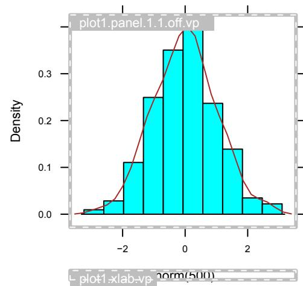

Figure 4: Annotating the simple lattice plot.

## Changes to graphical objects

All **grid** drawing functions create graphical objects representing the graphical output. This is good because it makes it possible to manipulate these objects to modify the current scene, but there needs to be a coherent mechanism for working with these objects.

There are several new functions, and some existing functions have been made more flexible, to provide a consistent and straightforward mechanism for accessing, modifying, and removing graphical objects.

All **grid** functions that produce graphical output, also create a graphical object, or grob, that represents the output, and there are functions to access, modify, and remove these graphical objects. This can be used as an alternative to modifying and rerunning the R code to modify a plot. In some situations, it will be the only way to modify a low-level feature of a plot.

Consider the output from the simple viewport example (shown in Figure 2). There are seven pieces of output, each with a corresponding grob: two rectangles, “`rect1`” and “`rect2`”; two lines, “`line1`” and “`line2`”; and three sets of circles, “`circles1`”, “`circles2`”, and “`circles3`”. A particular piece of output can be modified by modifying the corresponding grob; a particular grob is identified by its name.

The names of all (top-level) grobs in the current scene can be obtained using the `getNames()` function.[^5]

```
> getNames()

[1] "rect1"   "circles1" "line1"   "rect2"
[5] "circles2" "line2"   "circles3"
```

The following code uses the `grid.get()` function to obtain a copy of all of the grobs. The first argument specifies the names(s) of the grob(s) that should be selected; the `grep` argument indicates whether the name should be interpreted as a regular expression; the `global` argument indicates whether to select just the first match or all possible matches.

```
> grid.get(".*", grep=TRUE, global=TRUE)

(rect[rect1], circle[circles1], lines[line1],
 rect[rect2], circle[circles2], lines[line2],
 circle[circles3])
```

The value returned is a `gList`; a list of one or more grobs. This is a useful way to obtain copies of one or two objects representing some portion of a scene, but it does not return any information about the context in which the grobs were drawn, so, for example, just drawing the `gList` is unlikely to reproduce the original output (for that, see the `grid.grab()` function below).

The following code makes use of the `grid.edit()` function to change the colour of the grey circles to black (see Figure 5). In general, most arguments provided in the creation of the output are available for editing (see the documentation for individual functions). It should be possible to modify the `gp` argument for all grobs.

```
> grid.edit("circles3", gp=gpar(col="black"))
```

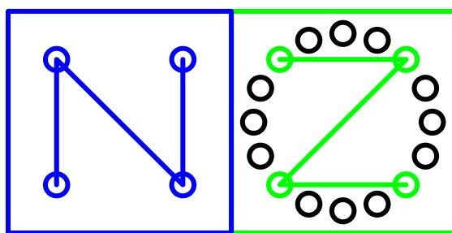

Figure 5: Editing grid output.

The following code uses `grid.remove()` to delete all of the grobs whose names end with a “2” – all of the blue output (see Figure 6).

```
> grid.remove(".+2$", grep=TRUE, global=TRUE)
```

[figure not shown]

Figure 6: Deleting grid output.

These manipulations are possible with any **grid** output. For example, in addition to lots of viewports, a **lattice** plot creates a large number of grobs and all of these can be accessed, modified, and deleted using the **grid** functions (an example is given at the end of the article).

### Hierarchical graphical objects

Basic grobs simply consist of a description of something to draw. As shown above, it is possible to get a copy of a grob, modify the description in a grob, and/or remove a grob.

It is also possible to create and work with more complicated graphical objects that have a tree structure, where one graphical object is the parent of one or more others. Such a graphical object is called a `gTree`. The functions described so far all work with `gTrees` as well, but there are some additional functions just for creating and working with `gTrees`.

In simple usage, a `gTree` just groups several grobs together. The following code uses the `grid.grab()` function to create a `gTree` from the output in Figure 6.

```
> nzgrab <- grid.grab(name="nz")
```

If we draw this `gTree` on a new page, the output is exactly the same as Figure 6, but there is now only one graphical object in the scene: the `gTree` called “nz”.

```
> grid.newpage()

> grid.draw(nzgrab)

> getNames()
```

```
[1] "nz"
```

This `gTree` has four children; the four original grobs that were “grabbed”. The function `childNames()` prints out the names of all of the child grobs of a `gTree`.

```
> childNames(grid.get("nz"))
```

```
[1] "rect1"    "circles1" "line1"
[4] "circles3"
```

A `gTree` contains viewports used to draw its child grobs as well as the grobs themselves, so the original viewports are also available.

```
> current.vpTree()
```

```
viewport[ROOT]->(
  viewport[leftvp],
  viewport[rightvp])
```

The `grid.grab()` function works with any output produced using **grid**, including **lattice** plots, and there is a similar function `grid.grabExpr()`, which will capture the output from an expression.[^6] The following code creates a `gTree` by capturing an expression to draw the histogram in Figure 3.

```
> histgrab <- grid.grabExpr(
  { trellis.par.set(canonical.theme("pdf"));
    print(hist1) },
  name="hist", vp="leftvp")
```

The `grid.add()` function can be used to add further child grobs to a `gTree`. The following code adds the histogram `gTree` as a child of the `gTree` called “nz”. An important detail is that the histogram `gTree` was created with `vp="leftvp"`; this means that the histogram gets drawn in the viewport called “leftvp” (i.e., in the left half of the scene). The output now looks like Figure 7.

```
> grid.add("nz", histgrab)
```

There is still only one graphical object in the scene, the `gTree` called “nz”, but this `gTree` now has five children: two lots of circles, one line, one rectangle, and a **lattice** histogram (as a `gTree`).

```
> childNames(grid.get("nz"))
```

```
[1] "rect1"    "circles1" "line1"
[4] "circles3" "hist"
```

The functions for accessing, modifying, and removing graphical objects all work with hierarchical graphical objects like this. For example, it is possible to remove a specific child from a `gTree` using `grid.remove()`.

When dealing with a scene that includes `gTrees`, a simple grob name can be ambiguous because, by default, `grid.get()` and the like will search within the children of a `gTree` to find a match.

Just as you can provide a viewport path in `downViewport()` to unambiguously specify a particular viewport, it is possible to provide a grob path in `grid.get()`, `grid.edit()`, or `grid.remove()` to unambiguously specify a particular grob.

A grob path is a list of grob names that must be matched in order from parent to child. The following code demonstrates the use of the `gPath()` function to create a grob path. In this example, we are going to modify one of the grobs that were created by **lattice** when drawing the histogram. In particular, we are going to modify the grob called “`plot1.xlab`” which represents the x-axis label of the histogram.

In order to specify the x-axis label unambiguously, we construct a grob path that identifies the grob “`plot1.xlab`”, which is a child of the grob called “`hist`”, which itself is a child of the grob called “`nz`”. That path is used to modify the grob which represents the xaxis label on the histogram. The xaxis label is moved to the far right end of its viewport and is drawn using a bold-italic font face (see Figure 8).

```
> grid.edit(gPath("nz", "hist", "plot1.xlab"),
  x=unit(1, "npc"), just="right",
  gp=gpar(fontface="bold.italic"))
```

## Summary

When a scene is created using the **grid** graphics system, a tree of viewport objects is created to represent the drawing regions used in the construction of the scene and a list of graphical objects is created to represent the actual graphical output.

Functions are provided to view the viewport tree and navigate within it in order to add further output to a scene.

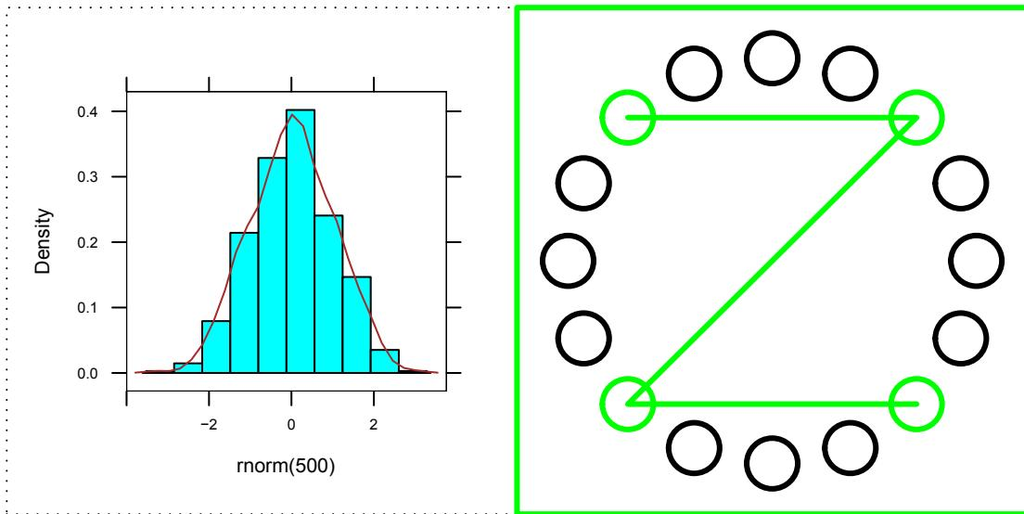

Figure 7: Grabbing grid output.

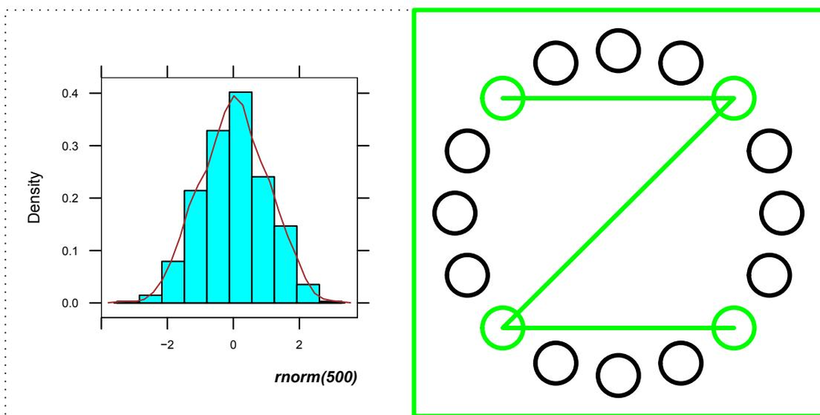

Figure 8: Editing a gTree.

Table 1: Summary of the new and changed functions in R 2.0.0 relating to viewports.

| **Function** | **Description** |
| --- | --- |
| `pushViewport()` | Create a region for drawing on the current graphics device. |
| `popViewport()` | Remove the current drawing region (does not delete any output). |
| `upViewport()` | Navigate to parent drawing region (but do not remove current region). |
| `downViewport()` | Navigate down to named drawing region. |
| `current.viewport()` | Return the current viewport. |
| `current.vpTree()` | Return the current tree of viewports that have been created on the current device. |
| `vpPath()` | Create a viewport path; a concatenated list of viewport names. |
| `viewport(..., name=)` | A viewport can have a name associated with it. |

Table 2: Summary of the new and changed functions since R 2.0.0 relating to graphical objects (some functions only available since R 2.1.0).

| **Function** | **Description** |
| --- | --- |
| `grid.get()` | Return a single grob or a `gList` of grobs. |
| `grid.edit()` | Modify one or more grobs and (optionally) redraw. |
| `grid.remove()` | Remove one or more grobs and (optionally) redraw. |
| `grid.add()` | Add a grob to a `gTree`. |
| `grid.grab()` | Create a `gTree` from the current scene. |
| `grid.grabExpr()` | Create a `gTree` from an R expression (only available since R 2.1.0). |
| `gPath()` | Create a grob path; a concatenated list of grob names. |
| `getNames()` | List the names of the top-level grobs in the current scene (only available since R 2.1.0). |
| `childNames()` | List the names of the children of a `gTree`. |
| `grid.rect(..., name=)` | Grid drawing functions can associate a name with their output. |

## References

P. Murrell. The grid graphics package. *R News*, 2(2): 14–19, June 2002. URL http://CRAN.R-project.org/doc/Rnews/.

D. Sarkar. Lattice. *R News*, 2(2):19–23, June 2002. URL http://CRAN.R-project.org/doc/Rnews/.

[^1]: The function used to be called `push.viewport()`.
[^2]: The output of `current.vpTree()` has been reformatted to make the structure more obvious; the natural output is all just on a single line.
[^3]: This low-level **grid** mechanism is general and available for any graphics output produced using **grid** including **lattice** output. An additional higher-level interface has also been provided specifically for **lattice** plots (e.g., the `trellis.focus()` function).
[^4]: The call to `trellis.par.set()` sets **lattice** graphical parameters so that the colours used in drawing the histogram are those used on a PDF device. This explicit control of the **lattice** “theme” makes it easier to exactly reproduce the histogram output in a later example.
[^5]: Only introduced in R version 2.1.0; a less efficient equivalent for version 2.0.0 is to use `grid.get()`.
[^6]: The function `grid.grabExpr()` is only available in R version 2.1.0; the `grid.grab()` function could be used instead by explicitly opening a new device, drawing the histogram, and then capturing it.